# Data Brief: 2020 Increases in Deaths in California

Note: This update includes data for Quarter 1, 2021 California Department of Public Health - Fusion Center - Last updated: 9.30.2021

This Data Brief (PDF version available here) presents an analysis of excess mortality (increase in deaths) for California in 2020, using California vital statistics death data (death certificates), and includes assessment of differential increases by race/ethnic group, age, and increases in deaths due to conditions other than COVID-19. This analysis is a follow-up to findings in the 2020 State of Public Health Report, part of the State Health Assessment.

# Summary

# Findings

## Deaths increased in 2020 compared to prior years

- There were 316,877 deaths in California in 2020 (corresponding to an age-adjusted all-cause death rate of 675.2 per 100,000 population), compared to 267,034 deaths in 2019 (rate of 583.1). This is a 15.8% increase in the death rate in California, and is the highest statewide death rate in the past 12 years.

### **Table 1 - Number, Age-Adjusted Rate, and Increase in Rate from Prior Year, Deaths from All Causes in California, 2017-2020**

| Year | Number of Deaths | Age-Adjusted Death Rate | % Increase in Rate from Prior Year |
| --- | --- | --- | --- |
| 2020 | 316877 | 675.219 | 0.15802119777732 |
| 2019 | 267034 | 583.08 | -0.0228108015706622 |
| 2018 | 266161 | 596.691 | -0.0193068151561868 |
| 2017 | 265439 | 608.438 |  |

- As the pandemic intensified throughout 2020, the increases in the rates accelerated. Comparing the 1st quarter of 2020 to the 1st quarter of 2019, death rates were similar, with just a 0.4% increase; then, comparing 2nd quarters, there was a 10.2% increase; comparing 3rd quarters, a 23.1% increase; and when comparing 4th quarters, a 30.7% increase.
- The rate in the 1st quarter of 2021 (Q1-2021) was higher than all quarterly rates in 2020, and much higher than any other recent prior quarter.

### **Figure 1 - All-Cause Death Rate by Quarter and Year, California 2017-2020 and Q1-2021**

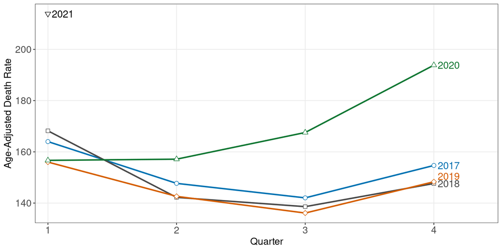

Download Figure 1 Data

## Deaths increased more among some race/ethnicity groups than others

- From 2019 to 2020, the death rate increased 34.3% among Latinos, 7.5% among Whites, and about 20% among other groups.

### **Figure 2 - Percentage Increase in Race-Specific Age-Adjusted Death Rates 2019 to 2020**

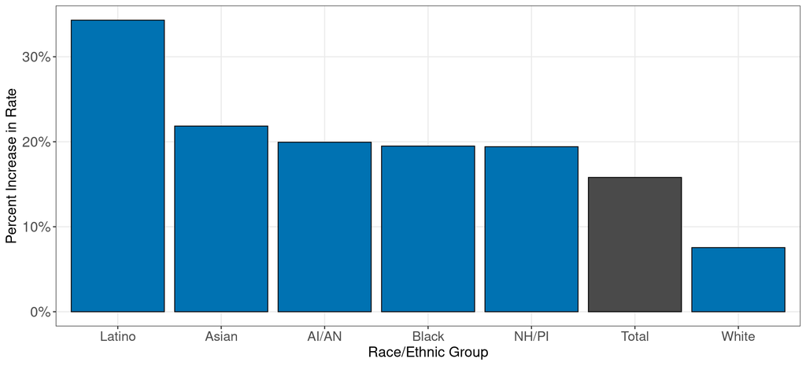

Download Figure 2 Data

- Deaths among all race/ethnic groups were higher in quarters 2, 3, and 4 of 2020 compared to the average rate of the corresponding 2017-2019 quarters. As the year progressed, these differences **within** each race/ethnic group increased for all race/ethnic groups, and disparities in rates **between** groups increased.
- These disparities are seen in Figure 3a by observing the increasing gap within any specific race/ethnicity group (dotted line compared to solid line), and by observing the increasingly larger gaps in some groups than others.
- These increases are all statistically significant for all groups. (See Appendix Figure Set 1)
- Rates continued to increase substantially for all race/ethnic groups in Q1-2021. In Q1-2021, the Latino rate surpassed the AI/AN rate.

### **Figure 3a - Trends in All Cause Age-Adjusted Mortality Rate by Race/Ethnicity by Quarter, 2020/Q1-2021 and 2017-2019 Average**

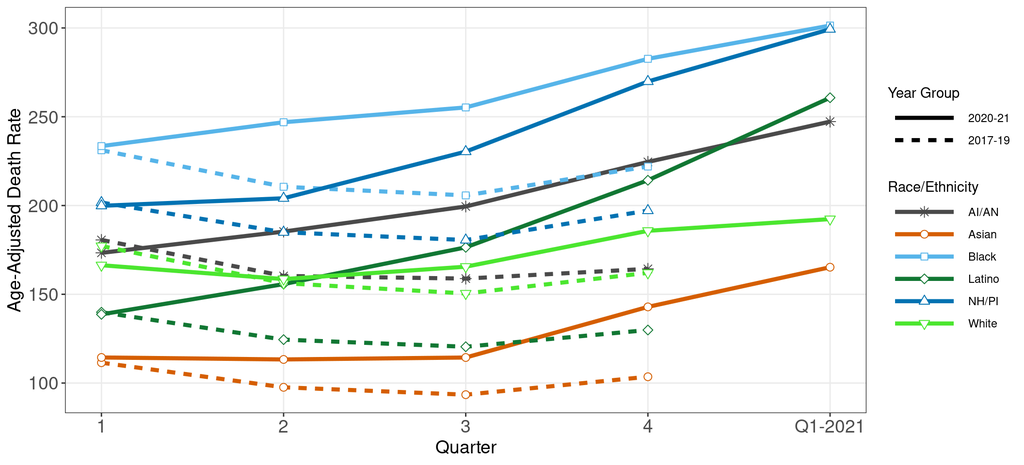

Download Figure 3a Data

### **Figure 3b - Percentage Increase in Age-Adjusted Death Rate by Quarter, 2020/Q1-2021 and 2017-2019 Average, by Race/Ethnicity**

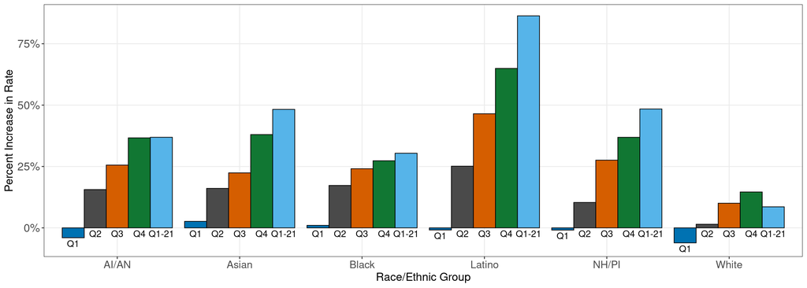

Download Figure 3b Data

## Causes of death other than COVID-19 also increased

- Aside from COVID-19, three conditions with large percent increases in deaths from 2019 to 2020 were drug overdose (46.9%), homicide (32.6%), and diabetes (17.7%), Table 2.
- The conditions with the largest absolute increases in number of deaths from 2019 to 2020 were Alzheimer’s disease and other dementias (3,624), ischemic heart disease (2,771), and drug overdoses (2,730).
- For drug overdose deaths, the increases are consistent with recent trends, albeit accelerated. For Alzheimer’s disease and other dementias, the increases are consistent with long-term increasing trends, but a sharp reversal of decreasing trends the past two years. But **for ischemic heart disease, the leading cause of death in California, the apparent increase is a concerning reversal of a steady downward trend of many prior years**. The **increase in homicide is also striking and alarming, in contrast to the encouraging decreases the last few years, and the long-term downward trend.** (For long-term trends in cause-specific deaths in California, see Appendix Figure Set 2 or the [California Community Burden of Disease Engine (CCB)](https://skylab.cdph.ca.gov/communityBurden/).)
- Regarding **decreases** from 2019 to 2020, **suicide/self-harm and lung cancers** both had noteworthy decreases.

### **Table 2 - 2017 to 2020, Selected Causes of Death, ordered by percent increase 2019 to 2020 [note: table is sortable]**

[interactive table not shown]

- Figure 4 below shows 2017-2020 quarterly trends in conditions that had large percentage or large absolute increases from 2019 to 2020 (detailed data in Appendix Table 1).
- As noted above, homicide deaths increased substantially in 2020, and strikingly by quarter. Homicide rates increased 23% in the 2nd quarter, 45% in the 3rd quarter and 57% in the 4th quarter 2020 compared to respective quarters in 2019.
- COVID-19 emerged in early 2020 and deaths increased rapidly not only in California, but almost everywhere, as a massive global pandemic. In the 4th quarter of 2020 and 1st quarter of 2021, COVID-19 was, by far, the leading cause of death in California.

### **Figure 4 - Quarterly Trend in Selected Causes of Death 2017-2020/Q1-2021**

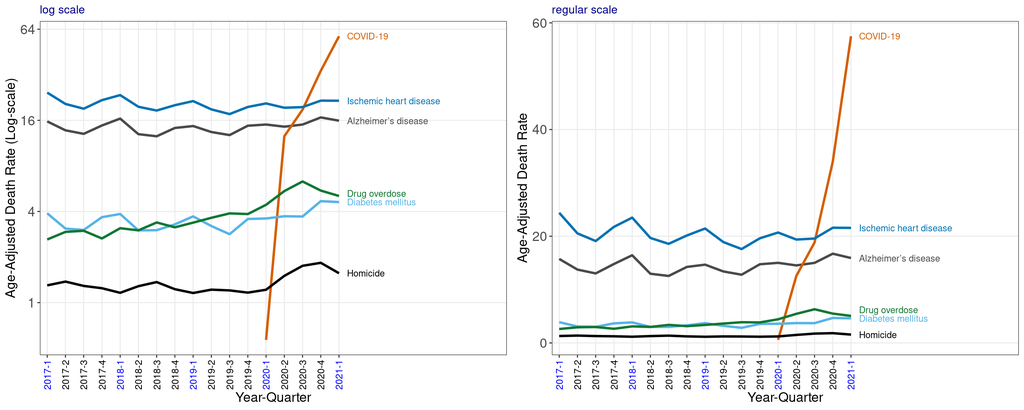

Download Figure 4 Data

## The amount of increase in deaths, and conditions associated with the increase, differed substantially by age and race/ethnicity

- In general, a large proportion of the increase in deaths among older persons was due to COVID-19 while a large proportion of the increase in deaths among younger persons was due to other conditions.
- As seen in Figure 5, the greatest percentage increases in the number of deaths were among older Latinos, younger Blacks, and 35-44 year-old AI/AN (detailed data in Appendix Figure Set 3 and Appendix Table 2).
- The striking increases among Blacks ages 5-14 and 15-24 are particularly concerning for a range of reasons. It is also important to note that these large percentage increases among young persons represent a smaller total number of deaths than among older persons.
- Of the 465 deaths (an increase of 156 deaths) among 15-24 year old Blacks in 2020, the greatest contributing causes were homicide, road injury, and drug overdose. Specifically, 138 (increase of 23 deaths) were due to homicides, 85 (increase of 31) to road injury, 76 (increase of 42) to drug overdoses, and 18 (increase of 8) to “ill-defined” conditions, some of which will be clarified in the coming months. These concerns are of course not restricted to just one race/ethnic group. For example, these same causes were leading contributors to the 1,966 deaths among Latinos aged 15-24 in 2020. Specifically, 467 (increase of 242 deaths) were due to drug overdoses, 333 (increase of 84) to homicide, 418 (increase of 71) to road injury, as well as 61 (increase of 33) to “ill-defined” conditions and 52 to COVID-19. These cause-specific data by race/ethnicity and age are available in Appendix Table 3.
- Of the 106 deaths (an increase of 46 deaths) among 35-44 year old AI/AN in 2020, the greatest contributing causes were drug overdose, 22 (increase of 14 deaths) and road injury, 11 (increase of 6).

### **Figure 5 - Percent Increase in Number of Deaths 2019 to 2020 by Age Group and Race/Ethnicity and Proportion of Increase due to COVID-19**

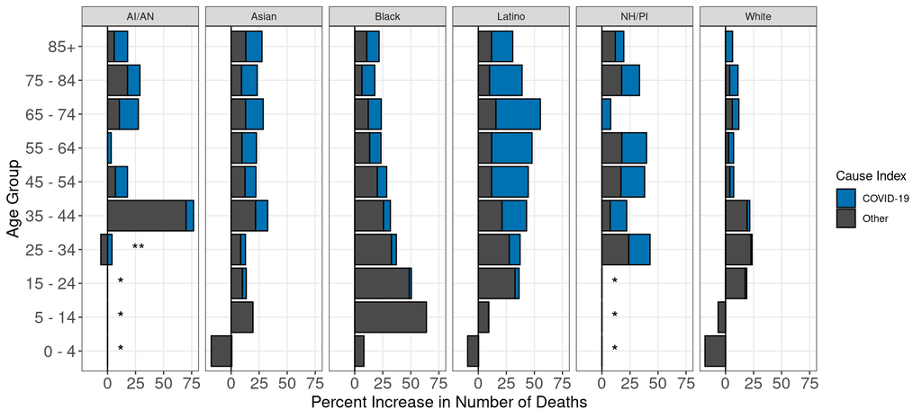

##### Note: The “cause index” is, rather than a direct proportion, the ratio of the number of COVID-19 deaths in 2020 to the total increase in deaths from 2019 to 2020, and is truncated at 1.0. See the Methods section for details.

##### *For younger NH/PI and AI/AN age groups, the underlying number of deaths for 2019 and/or 2020 is <25 so data are not shown

##### **25-34 year old AI/AN experienced an overall decrease in deaths, and had a small number of deaths from COVID-19

Download Figure 5 Data

# Data, Methods, and Technical Notes

- This Data Brief was developed as a part of the broader [State Health Assessment](https://letsgethealthy.ca.gov/the-story/), and builds on the 2020 State of Public Health report.
- Death data are from the California Integrated Vital Records (CalIVRS) system, based on death certificates/reports transmitted to the California Department of Public Health, Center for Health Statistics and Informatics (CHSI):
  - 2020 and Quarter 1, 2021 deaths are based on data received from CHSI on July 12, 2021. Additional 2020 and Q1-2021 deaths will continue to be reported subsequent to that date, and cause of death information will change for some deaths already reported. However, based on examination of the data and historic precedence, it is highly unlikely that the statewide patterns and trends described in the report will change in any meaningful way once final data are available.
- All death numbers and rates in this analysis are based only on the primary underlying cause of death, not on any secondary contributing factors (i.e. no “multiple cause of death” codes are included).
- Deaths in this Data Brief are based on this vital statistic data, and death numbers may differ from numbers reported based on other systems. In particular, numbers of deaths from COVID-19 may differ from COVID-19 death numbers posted on CDPH, National, or other web sites. Those sites can include reports of deaths from sources other than death certificates and/or on deaths where COVID-19 is not listed as the “primary” cause of death.
- The grouping of ICD-10 cause of death codes into condition categories is based on the California Burden of Disease System, a California-modified version of the Global Burden of Disease system. Details of this system are available on the [California Community Burden of Disease Engine (CCB)](https://skylab.cdph.ca.gov/communityBurden/), in the **About -> Technical Documentation** tab. Of specific note for this Data Brief:
  - “COVID-19” is based on ICD-10 codes U07.1.
    - [March 2000 National Center for Health Statistics guidance on new ICD code for COVID-19 deaths](https://www.cdc.gov/nchs/data/nvss/coronavirus/Alert-2-New-ICD-code-introduced-for-COVID-19-deaths.pdf)
    - [April 2021 CDC report supporting the accuracy of COVID-19 mortality surveillance](https://www.cdc.gov/mmwr/volumes/70/wr/mm7014e2.htm?s_cid=mm7014e2_w)
  - The “Drug overdose” condition includes “accidental poisonings by drugs” codes (X40-X44) and “substance use disorder codes” (F11-F16, F18, F19), but not “alcohol use disorder” (F10). The drug overdose condition also includes “newborn (suspected to be) affected by maternal use of drugs of addiction” (P044).
- Population denominator data for rate calculations are from the California Department of Finance (DOF) [Population Projections (Baseline 2019)](https://www.dof.ca.gov/forecasting/demographics/Projections/) Table P-3: Complete State and County Projections Dataset.
- Unless otherwise specified, the term “rate” throughout this Data Brief means age-adjusted death rate per 100,000 population.
- Age-adjusted rates are calculated using the “direct” method, with the CDC [standard 2000 projected U.S. population](https://www.cdc.gov/nchs/data/statnt/statnt20.pdf) published by CDC/NCHS in January 2001–specifically, Table 2, Distribution #1 was used, but with age groups <1 and 1-4 combined.
- Excess mortality measures how much higher (or lower) mortality is in one time period or group compared to another. Excess mortality in the context of the COVID-19 pandemic is generally the mortality in a particular COVID-19-impacted time period, like 2020, compared to a prior period not impacted by COVID-19, like 2019. Other periods can be used too, like specific ranges of weeks, months or quarters. Excess mortality in this Brief compares rates in 2020 to ‘baseline’ rates in 2019, or the average of 2017-2019, using full year or quarters .
- Race/ethnicity is grouped and coded using standard CDPH methods and is detailed in the CCB technical documentation. Persons coded as “multi-race” are excluded from race-specific data, because numerator-denominator mis-alignment makes such rates uninterpretable.
  - Issues related to classification of multirace persons are likely to become increasingly important in California; standardized procedures and data collection systems are needed.
- The data in **Table 2** were first restricted to causes of death for which there were > 500 deaths in any year, 2017-2020. Then, among those causes, the data were restricted to causes that had among the top five relative (percent change in age-adjusted death rate) or absolute (change in number of deaths) increases from 2019 to 2020 or among the bottom three relative or absolute decreases.
- The data in **Figure 4 and Appendix Table 2** are restricted to causes of death for which there were > 500 deaths in any quarter of any year, 2017-2020, and among those the causes that were among the top three relative or absolute increases from Quarter 2, 3 or 4 in 2019 to the same quarter in 2020.
  - Figure 4 also includes COVID-19 for reference, even though there is no prior year comparison.
  - Appendix Table 2 also includes causes of death among the bottom two respective relative or absolute decreases.
- For **Figure 5**, the overall length of each bar is the percent increase in the **number** of deaths from all cases from 2019 to 2020 in the specific age and race/ethnic group. The “Cause Index” was constructed by first calculating the ratio of the number of COVID-19 deaths (in 2020) in each group to the total increase in the number of deaths in that group. If that ratio was greater than 1.0 (i.e. the number of COVID-19 deaths in 2020 was greater than the increase in number of deaths from 2019 to 2020), the ratio was set to one. The COVID-19 proportion of each bar is the product of that ratio and that overall percent increase; the “Other cause” proportion is the remainder of each bar.
- All analysis and data display were conducted using R and this document was generated using R markdown. All data and numbers in this document were generated/extracted directly from the data; no numbers were “hand transcribed”. This approach provides internal documentation and facilitates updating, reproducibility, and reuse.
- All data and visualizations in the Data Brief are available at the county level, at the request of the respective county health department.
- An Excel file with data for all charts above can be downloaded here.

# Discussion

# Additional Exploratory Analyses

- Questions from partners and ongoing analyses since the original Brief version have resulted in the addition of the three exploratory sections below:

## All-cause age-adjusted mortality rate is extremely closely related, in inverse, to life expectancy at birth. Life Expectancy is more commonly used and a more intuitive measure.

### **Figure 6 - Life Expectancy Trend by Race/Ethnicity, 2000-2020**

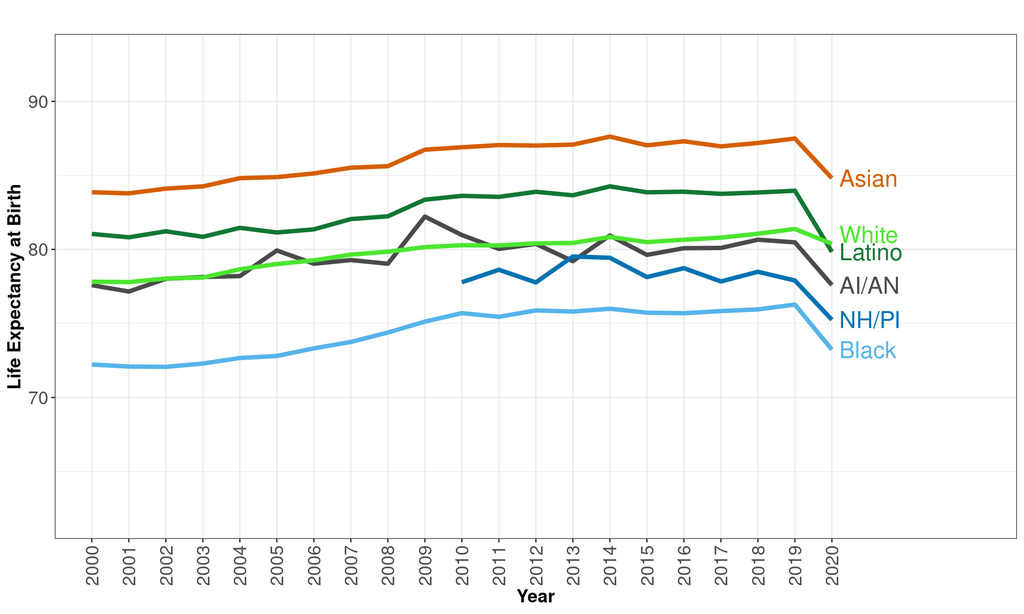

## Social Determinants of Health

- Excess mortality was associated with Social Determinants of Health, including Poverty, House Overcrowding, and Limited English Proficiency, in preliminary/exploratory analyses
- SDOH are based on the community level (census tract) not individual level, using the [Krieger/Harvard Public Health Disparities Geocoding approach](https://www.hsph.harvard.edu/thegeocodingproject/)
- Both SDOH and race/ethnicity are independently associated with excess mortality. The patterns of SDOH and excess mortality different across r/e groups. These interrelationships are complex, difficulty to measure, and important.

### **Figure 7 - Increase in Death Rate by Race/Ethnicity, and Social Determinants of Health in 2020**

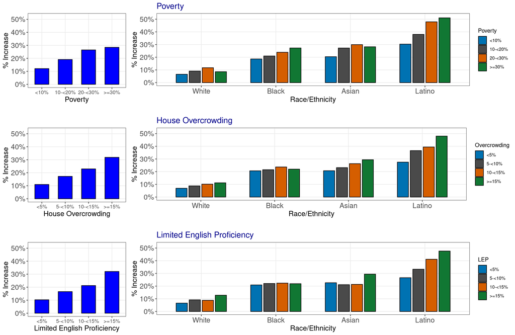

## Different calculation methods can yield different insights into the magnitude and disparities of excess mortality

- In the information above, excess mortality is calculated as the **percent increase** in a rate from 2019 to 2020. Other methods can be used, including a method that calculates excess mortality as the increase in the **number** of death divided by the population size – this method has been used in [a published letter](https://jamanetwork.com/journals/jamainternalmedicine/fullarticle/2774273) assessing excess mortality in California.
- Part A in the chart below replicates Figure 2 above, and indicates that Latinos have the highest excess mortality based on percent increase. Part B below uses the other method and indicates that Blacks have the highest excess mortality based on the “excess mortality rate”; and indicates that both American Indian/Alaska Natives and Native Hawaiian/Pacific Islanders have a higher excess mortality rate than Latinos.
- The “conclusions” from the two methods differ because of the different ways the methods take into account the rate in the baseline period and the population size. Both of these methods are reasonable and provide different insights.

### **Figure 8 - Excess Mortality Measures Comparison**

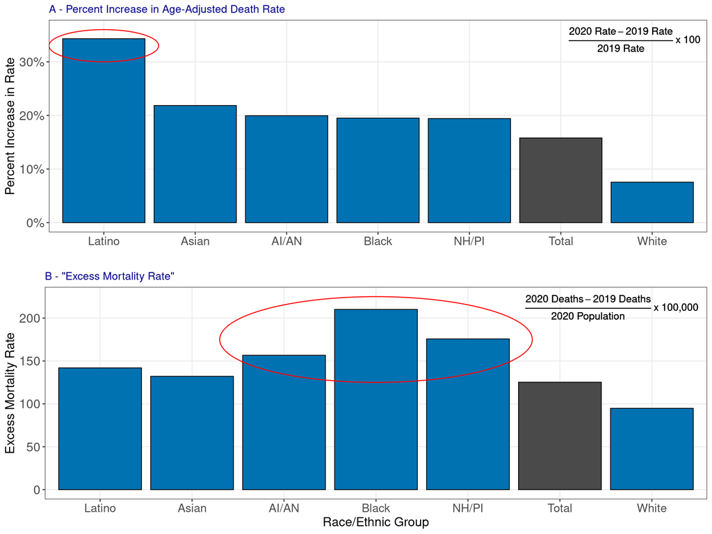

# Conclusion

- Deaths increased substantially in California in 2020 in large part because of COVID-19 and, importantly, other causes of death also increased. These increases differed by race/ethnicity and age. Further investigation of these changes is crucial to address the immediate situation and to prepare for the future.

# Links to related information

### National excess mortality

- [COVID-19 is the Number One Cause of Death in the U.S. in Early 2021 (Kaiser Family Foundation Data - 2.22.2021)](https://www.healthsystemtracker.org/brief/covid-19-is-the-number-one-cause-of-death-in-the-u-s-in-early-2021/)
- [Leading Causes of Death in the US for 2020 (National Center for Health Statistics - JAMA - 3.31.2021)](https://jamanetwork.com/journals/jama/fullarticle/2778234)
- [Excess Deaths From COVID-19 and Other Causes in the US (JAMA - 4.2.2021)](https://jamanetwork.com/journals/jama/fullarticle/2778361)
- [Learning From Excess Pandemic Deaths - Editorial related to article above (JAMA 4.2.2021)](https://jamanetwork.com/journals/jama/fullarticle/2778362)
- [Excess Deaths Associated with COVID-19 (CDC Dashboard)](https://www.cdc.gov/nchs/nvss/vsrr/covid19/excess_deaths.htm)

### California excess mortality

- [Excess Mortality in California During the Coronavirus Disease 2019 Pandemic, March to August 2020 (UCSF team - JAMA Internal Medicine research letter 5.2021)](https://jamanetwork.com/journals/jamainternalmedicine/fullarticle/2774273)
- [COVID-19 mortality in California based on death certificates: disproportionate impacts across racial/ethnic groups and nativity (USC Team - Annals of Epidemiology June 2021)](https://www.sciencedirect.com/science/article/pii/S1047279721000430)
- [40,000+ excess deaths in 2020, and other things we learned from California death data (The Mercury News 1.27.2021)](https://www.mercurynews.com/2021/01/27/40000-excess-deaths-in-2020-and-other-things-we-learned-from-california-death-data/)

### California excess mortality - occupational sector

- [Excess mortality associated with the COVID-19 pandemic among Californians 18–65 years of age, by occupational sector and occupation - UCSF team (PLOS ONE 6.4.2021)](https://journals.plos.org/plosone/article?id=10.1371/journal.pone.0252454)
- [Pandemic’s Toll on California Workers in High Risk Industries (UC Merced Fact Sheet 4.2021)](https://clc.ucmerced.edu/sites/clc.ucmerced.edu/files/page/documents/fact_sheet_-_the_pandemics_toll_on_california_workers_in_high_risk_industries.pdf) and [related newsletter](https://www.universityofcalifornia.edu/news/analysis-shows-toll-pandemic-high-risk-workers)